# Homework_2_TianranZhang

Tianran Zhang

9/25/2019

The github repository link is : https://github.com/Creatran/Homework_2.git

# 1. Performed tasks with a single data verb

## a. Find the average of one of the variables.

original_table %>% summarise(m = mean(variable))

## b. Add a new column that is the ratio between two variables.

mutate(original_table, r = variable1/variable2)

## c. Sort the cases in descending order of a variable.

arrange(desc(variable))

## d. Create a new data table that includes only those cases that meet a criterion

new_table <- filter(original_table, criterion1, criterion2, …)

## e. Prodece a data frame that has the same cases but only the variables A and X.

new_table <- select(original_table, A, X)

# 2. Use the nycflights13 pacjage and the flights data frame to answer the following questions:

## a. What month had the highest proportion of cancelled flights?

```r
f1 <- flights %>%
  mutate(cancelled = ifelse(is.na(dep_time), 1, 0)) %>%
  group_by(month) %>%
  summarise(cancelled_sum = sum(cancelled), N = n()) %>%
  mutate(cancelled_prop = cancelled_sum/N) %>%
  arrange(desc(cancelled_prop))


paste('The month ', f1$month[1], ' had the highest proportion of cancelled flights, and the rate is', round(f1$cancelled_prop[1]* 100, 1), '%')
```

```
## [1] "The month  2  had the highest proportion of cancelled flights, and the rate is 5.1 %"
```

## b. What month had the lowest?

```r
n <- nrow(f1)
paste('The month ', f1$month[n], ' had the highest proportion of cancelled flights, and the rate is', round(f1$cancelled_prop[n]*100, 1), '%')
```

```
## [1] "The month  10  had the highest proportion of cancelled flights, and the rate is 0.8 %"
```

## c. Interpret any seasonal patterns with a graphic.

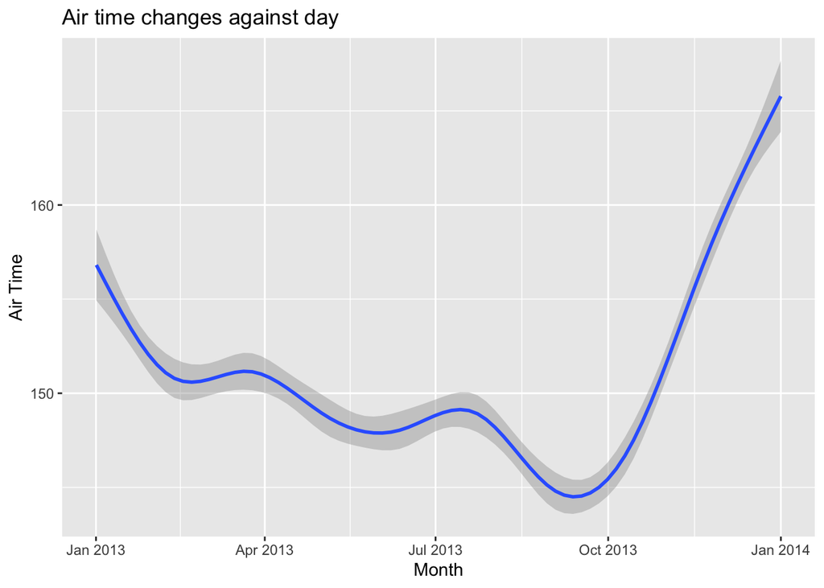

```r
# Consider the air time changes with day
ggplot(data = flights, aes(x = time_hour, y = air_time)) +
  geom_smooth() +
  ggtitle("Air time changes against day") +
  xlab("Month") +
  ylab("Air Time")
```

From the plot we can see that the air time change seasonaly, The time length turns shorter in summer and grows longer in winter.

## d. What plane traveled the most times from New York City airports from 2013?

```r
f1 <- flights %>%
  filter(is.na(tailnum) == FALSE) %>%
  group_by(tailnum) %>%
  summarise(N = n()) %>%
  arrange(desc(N))

head(f1, 1)
```

```
## # A tibble: 1 x 2
##   tailnum     N
##   <chr>   <int>
## 1 N725MQ    575
```

The plane N725MQ traveled the most times from New York City airports in 2013, with N = 575 flights.

## e. Plot the number of trips per week over the year.

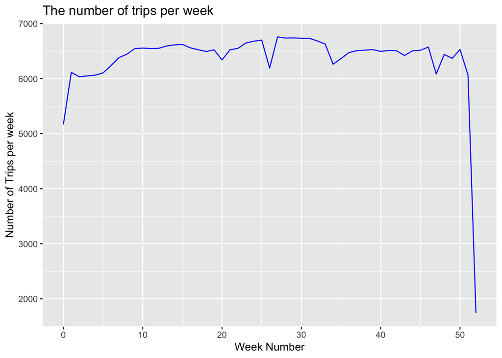

```r
f2 <- flights %>%
  mutate(weeknum = as.integer(strftime(time_hour, format = "%W"))) %>%
  group_by(weeknum) %>%
  summarise(n_trips = n())

ggplot(data = f2) +
  geom_line(aes(x = weeknum, y = n_trips), color = 'blue') +
 # coord_trans(y = 'log10') +
  xlab("Week Number") +
  ylab("Number of Trips per week") +
  ggtitle("The number of trips per week")
```

# 3.

## a. The oldest plane that flew from NYC airports in 2013

```r
head(planes)
```

```
## # A tibble: 6 x 9
##   tailnum  year type       manufacturer   model  engines seats speed engine
##   <chr>   <int> <chr>      <chr>          <chr>    <int> <int> <int> <chr>
## 1 N10156   2004 Fixed win… EMBRAER        EMB-1…       2    55    NA Turbo…
## 2 N102UW   1998 Fixed win… AIRBUS INDUST… A320-…       2   182    NA Turbo…
## 3 N103US   1999 Fixed win… AIRBUS INDUST… A320-…       2   182    NA Turbo…
## 4 N104UW   1999 Fixed win… AIRBUS INDUST… A320-…       2   182    NA Turbo…
## 5 N10575   2002 Fixed win… EMBRAER        EMB-1…       2    55    NA Turbo…
## 6 N105UW   1999 Fixed win… AIRBUS INDUST… A320-…       2   182    NA Turbo…
```

```r
flights_dep <- flights %>%
  filter(is.na(tailnum) == FALSE) %>%
  group_by(tailnum) %>%
  summarise()

plane_nyc2013 <- left_join(flights_dep, planes, by = c("tailnum")) %>%
  select(tailnum, year) %>%
  arrange(year)
head(plane_nyc2013, 2)
```

```
## # A tibble: 2 x 2
##   tailnum  year
##   <chr>   <int>
## 1 N381AA   1956
## 2 N201AA   1959
```

The oldest plane that flew from New York City airports in 2013 is the plane with tailnum N381AA, which is a plane born in 1956.

## b. Number of airplanes flew from NYC included in the planes table

```r
nflights <- inner_join(flights_dep, planes, by = c("tailnum"))
nrow(nflights)
```

```
## [1] 3322
```

There are 3322 airplanes that flew from New York City included in the planes table.

## c. Number of planes with a missing manufacture date.

```r
planes %>%
  filter(is.na(year)) %>%
  mutate(N = n()) %>%
  group_by(N) %>%
  summarise() %>%
  pull()
```

```
## [1] 70
```

There are 70 planes in the planes table have a missing manufacture date.

## d. The five most common manufacturers.

```r
planes %>%
  group_by(manufacturer) %>%
  summarise(N = n()) %>%
  arrange(desc(N)) %>%
  head(5)
```

```
## # A tibble: 5 x 2
##   manufacturer         N
##   <chr>            <int>
## 1 BOEING            1630
## 2 AIRBUS INDUSTRIE   400
## 3 BOMBARDIER INC     368
## 4 AIRBUS             336
## 5 EMBRAER            299
```

The 5 most common manufacturers are BOEING, AIRBUS INDUSTRIE, BOMBARDIER INC, AIRBUS, EMBRAER.

# 4.

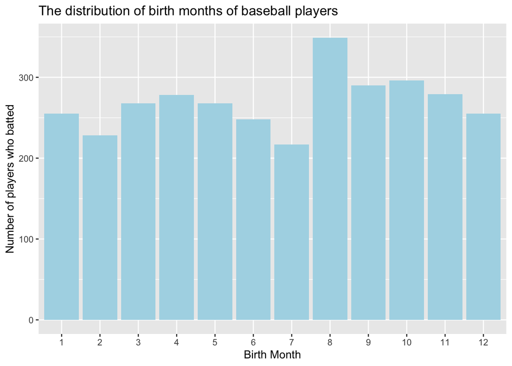

```r
Bat_players <- left_join(Master, Batting, by = c("playerID")) %>%
  filter(yearID>=2000 & yearID <= 2009, is.na(bats) == FALSE) %>%
  group_by(playerID, birthMonth) %>%
  summarise()

Bat_players$birthMonth <- factor(Bat_players$birthMonth)

ggplot(data = Bat_players, aes(x = birthMonth)) +
  geom_bar(fill = 'light blue') +
  xlab("Birth Month") +
  ylab("Number of players who batted") +
  ggtitle("The distribution of birth months of baseball players")
```

# 5.

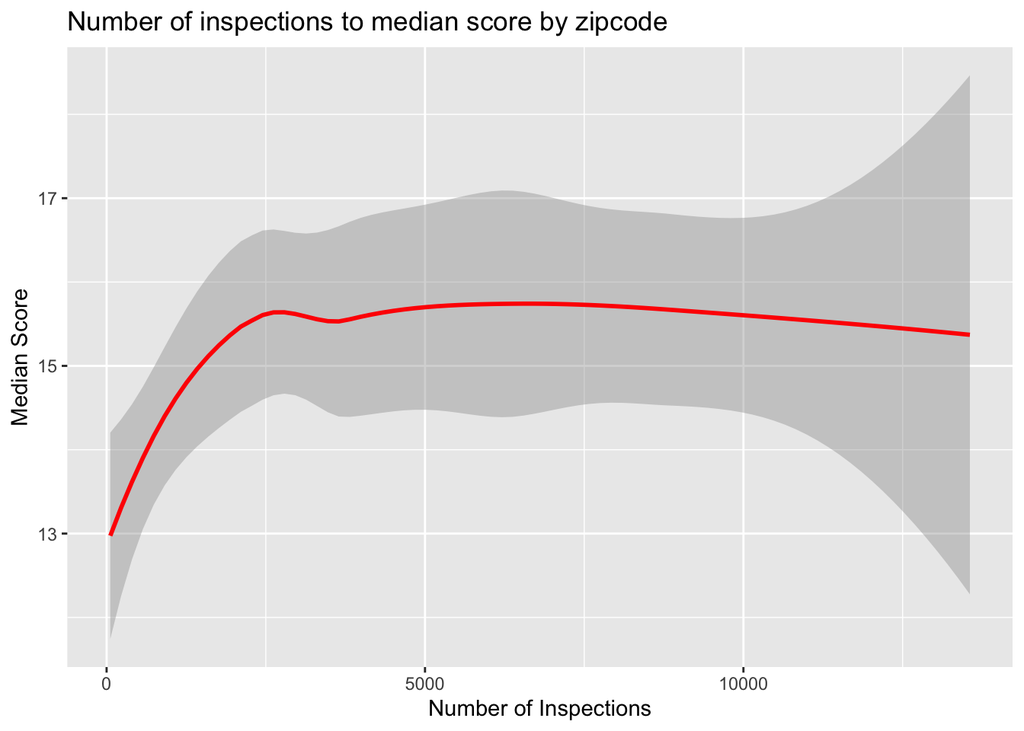

```r
Violations_score <- Violations %>%
  filter(boro == 'MANHATTAN') %>%
  mutate(score = ifelse(is.na(score), 0, score)) %>%
  group_by(zipcode) %>%
  summarise(inspection_num = n(), median_score = median(score)) %>%
  filter(inspection_num >= 50)

ggplot(data = Violations_score) +
  geom_smooth(aes(x = inspection_num, y = median_score), color = 'red') +
  ylab("Median Score") +
  xlab("Number of Inspections") +
  ggtitle("Number of inspections to median score by zipcode")
```

The plot shows that as the number of inspections increase from 0 to 2500, the median score grows higher. As the number of inspections increase beyond 2500, the mean value of median score reach a stabilization at around 15.7, while the standard deviation of median score towards number of inspections becomes larger as the inspections number increases higher than 10000.